# Practical Machine Learning Course Project

Mohamad Nazir Ismail

January 28, 2016

# Project Executive Summary

We will also use your prediction model to predict 20 different test cases. As below request:-

-Submission should consist of a link to a Github repo with your R markdown and compiled HTML file describing your analysis. Please constrain the text of the writeup to < 2000 words and the number of figures to be less than 5. It will make it easier for the graders if you submit a repo with a gh-pages branch so the HTML page can be viewed online (and you always want to make it easy on graders.

- And apply your machine learning algorithm to the 20 test cases available in the test data above. Please submit your predictions in appropriate format to the programming assignment for automated grading. See the programming assignment for additional details.

# Setting-up The Environment

# Splitting the Data

The data is already been splitted into the testing set and training set, both the files are loaded separately. As we can see, there are 19622 rows and 160 columns of data available form the training data set and 20 rows and 160 columns of testing data set.

```r
testingori <- read.csv("pml-testing.csv", na.strings=c("NA",""), strip.white=T)
training <- read.csv("pml-training.csv", na.strings=c("NA",""), strip.white=T)
dim(training)
```

```
## [1] 19622   160
```

```r
dim(testingori)
```

```
## [1]  20 160
```

# Trimming Variable

In the 160 variables, there are a lot of variables that will not contribute to the analysis. In this section, we are removing all those columns that contain “NA” and has no numeric value from the training data set. This leaves us with only 60 variables to review.

```r
training2 <- training[ , colSums(is.na(training)) == 0]
dim(training2)
```

```
## [1] 19622    60
```

After we review the variables, the first 7 variables are information that are not significant for our analysis. Thus we are removing those 7 non-relevant variables. This process will reduce the variables further to 53 variables with the last variable being classe, the variable that we are predicting.

```r
training3<-training2[,-c(1:7)]
dim(training3)
```

```
## [1] 19622    53
```

After last step in preparing the baseline training data is to look at the correlations between the variables in our dataset. We may want to remove highly correlated predictors from our analysis and replace them with weighted combinations of predictors. This may allow a more complete capture of the information available.

```r
library(corrplot)
corrmatrix<- cor(na.omit(training3[sapply(training3, is.numeric)]))
dim(corrmatrix)
```

```
## [1] 52 52
```

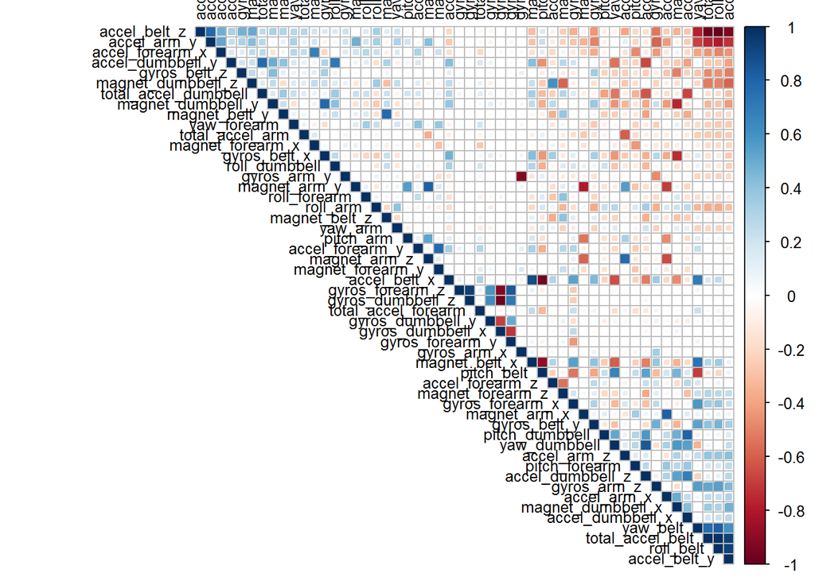

```r
corrplot(corrmatrix, order = "FPC", method = "square", type = "upper", tl.cex = 0.8, tl.col = rgb(0, 0, 0))
```